# Differential Expression Report

Project: Differential Gene Expression and Pulmonary Function in Vaping LatinX Adolescents Analyst: Trent Hawkins Investigator(s): Sunita Sharma, MD Report generated: October 25, 2022

# Introduction

The purpose of this report is to present results from differential expression analysis for Dr. Sunita Sharma’s study assessing the effects of vaping on pulmonary function in adolescents. Additional background and the pre-processing steps taken can be found in the ‘Metadata Exploratory Report’ included in this series of statistical reports.

# Methods

*All analyses performed using R version 4.2.1 (2022-06-23)*

### Clinical Data Processing

Vape Status is self-reported and defined by vaping within the 6-month period leading up to the survey. In order to obtain the vape status and recruitment center metrics, responses were aggregated over several survey questions. This process is more clearly described in the ‘Exploratory Report’.

### Gene-Count Processing

*Annotation: Ensembl annotation for GrCH 39 ver. 37*  
*Removal of Unwanted Variance: edgeR 3.39.6 and RUVSeq 1.31.0*  
*Differential Expression Analysis: DESeq2 1.37.5*

Gene filtering and RUVr normalization were previously conducted for the exploratory analysis. An abbreviated version of the results will be presented here, but further detail can be found in the exploratory report. The model used to obtain the residuals for RUVr included *vape status*, *sex*, and *age* as model covariates.

Notice that recruitment center was not incorporated into this model, as we are *not* interested in keeping any variability based on recruitment center in the data set.

### Model Fitting

The differential expression analysis will use RUVr with k = 2 factors. Gene counts were fit using negative binomial models from the R package DESeq2. To account for multiple testing the False Discovery Rate (FDR) was calculated, and significance set at FDR < 0.05.

To parse out the effects that vape status and recruitment center have on gene expression, the following models were fit and compared using Likelihood Ratio Tests (LRTs) in DESeq2 :

Full Model: $raw \ read \ count \sim vape \ status + recruitment \ center + sex + age + ruv_1 + ruv_2$

Reduced Model (testing vape status and recruitment center): $raw \ read \ count \sim \ sex + age + ruv_1 + ruv_2$

Reduced Model (testing vape status): $raw \ read \ count \sim recruitment \ center + sex + age + ruv_1 + ruv_2$

Reduced Model (testing recruitment center): $raw \ read \ count \sim vape \ status + sex + age + ruv_1 + ruv_2$

Likelihood Ratio Tests (LRTs) were used to compare full and reduced models. All LRTs used the same full model, which included vape status (binary Y/N) and recruitment center (3-level categorical), sex (binary M/F), age (continuous), and two normalization factors from the RUVr Analysis. In each scenario above, the LRT examines if the additional covariates included in the full model and not the reduced model significantly increase model fit. The reduced model for vape status and recruitment center tests if vape status *and* recruitment center (together) significantly explain gene expression after adjusting for sex, age, and the two RUV factors. The other models test similarly, but only for one covariate at a time. The model we are most interested in is the reduced model testing only vape status. The others were included to investigate the presence of recruitment center bias in the data.

# Results

### Table 1: Subject Demographics

|  | Did Not Vape in Last 6 Months (N=36) | Vaped in Last 6 Months (N=11) | Total (N=47) |
| --- | --- | --- | --- |
| **Sex** |  |  |  |
| Female | 17 (47.2%) | 8 (72.7%) | 25 (53.2%) |
| Male | 19 (52.8%) | 3 (27.3%) | 22 (46.8%) |
| **Age (yrs)** |  |  |  |
| Mean (SD) | 14.6 (1.4) | 14.9 (1.4) | 14.7 (1.4) |
| Range | 12.0 - 17.0 | 13.0 - 17.0 | 12.0 - 17.0 |
| **Recruitment Center** |  |  |  |
| Aurora | 14 (38.9%) | 0 (0.0%) | 14 (29.8%) |
| CommCity/Denver | 13 (36.1%) | 1 (9.1%) | 14 (29.8%) |
| Pueblo | 9 (25.0%) | 10 (90.9%) | 19 (40.4%) |

### Figure 1: Select Subject Demographics by Vape Status

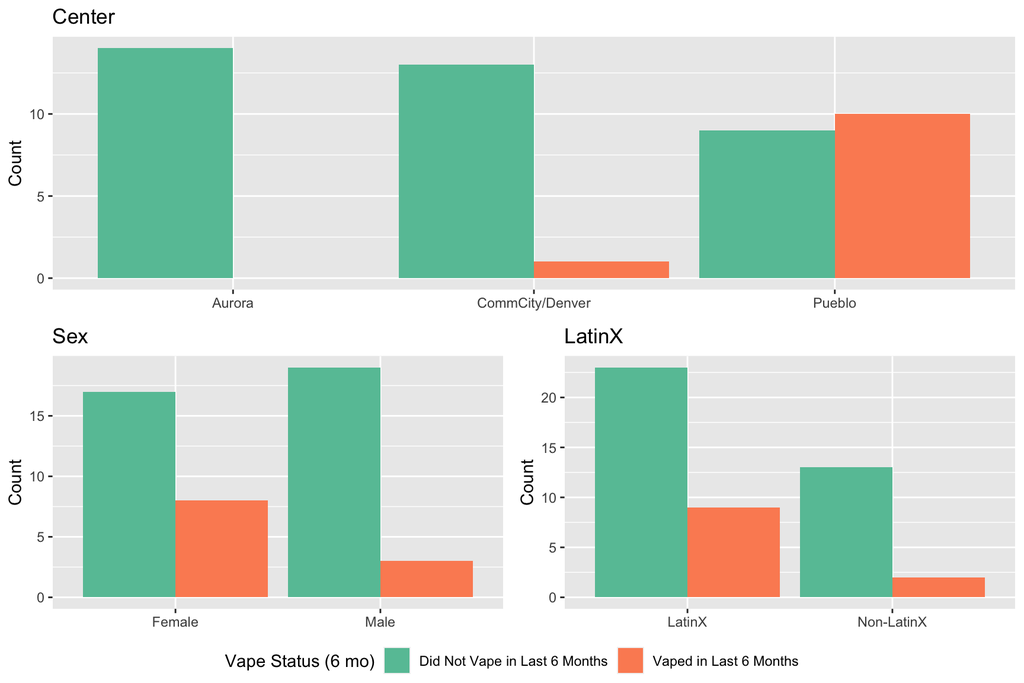

Due to the demographic imbalances present in the dataset, it is important to look into potential sources of multicollinearity or confounding. Figure 2 characterizes some of the relationships present in the data using Fischer’s Exact tests.

### Figure 2: Correlation of Model Predictors

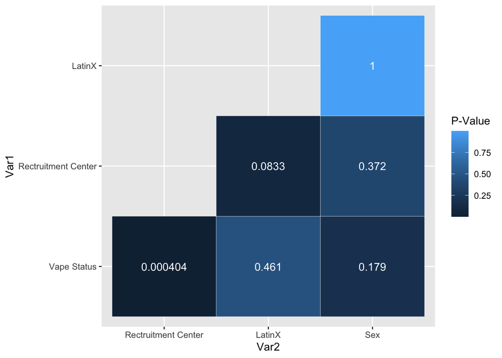

There is a significant correlation between vape status and recruitment center (p < 0.001). The t-test for vape status and age (p = 0.522) show no significant correlation.

*t-test: Vape Status and Age*

| Test Variable | Group 1 | Group 2 | Mean Group 1 | Mean Group 2 | t | df | p-value |
| --- | --- | --- | --- | --- | --- | --- | --- |
| Age | Did Not Vape in Last 6 Months | Vaped in last 6 months | 14.6 | 14.9 | -0.7 | 16.6 | 0.5 |

## Gene-Count Processing

There were **n = 47** samples present with both demographic and RNA-Seq data (see the Exploratory Report for further details). There were 60,651 genes before filtering out poor-quality genes. This analysis will include a total of **16,860** genes.

### Figure 3: Relative Log Expression and Principal Component Analysis for RUV

The Relative Log Expression (RLE) and Principal Component Analysis (PCA) of read counts for each sample both before and after transformation using RUVr with k = 2 factors. There was an initial concern for Sample 12 as an outlier.

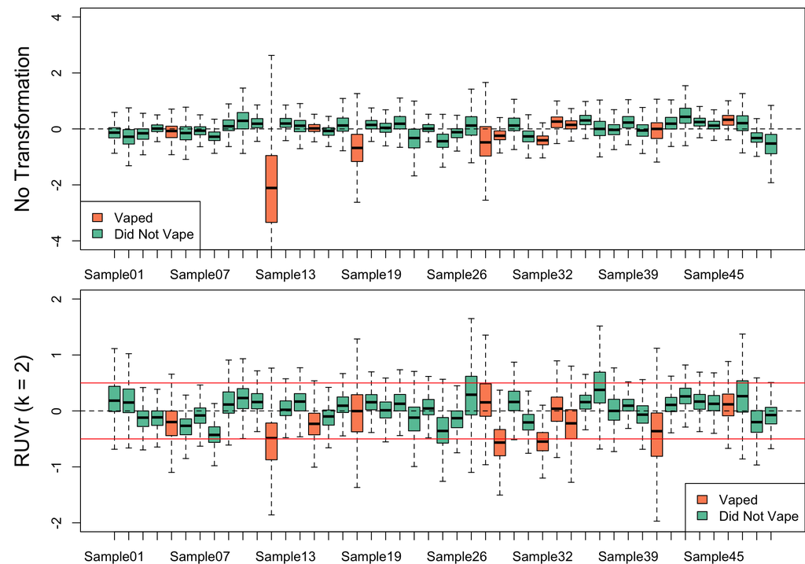

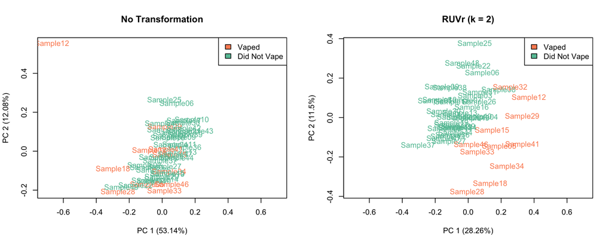

Using two normalization factors, Sample 12 is no longer a suspected outlier and overall, two factors sufficiently normalize the gene expression counts.

## Differential Expression Analysis

### Figure 4: P-value Distributions (Unadjusted)

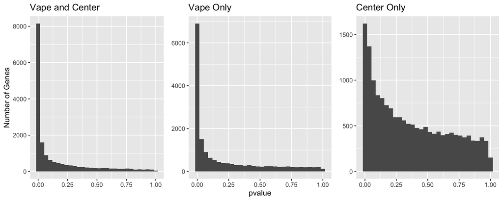

From the p-value histograms above, there is no evidence of poor model fit. Table 3 shows shows both the total number of significant genes for each model (FDR < 0.05) followed by the number of genes that were significant in only that model (FDR < 0.05). The *Center Only* model had 0 unique significant genes.

*Table 3: Summary of Significant LRT Results (Full Model the same across all tests)*

| Model | Total Significant Genes (FDR < 0.05) | Unique Significant Genes (FDR < 0.05) |
| --- | --- | --- |
| Vape and Center | 8,696 | 1,982 |
| Vape Only | 7,136 | 660 |
| Center Only | 366 | 0 |

To additionally check model results, Figures 5 - 7 box plots compare $\log_{10}$ transformed expression of the top 4 genes for each model as indicated by the smallest FDR.

### Figures 5: $\log_{10}$(RUV-Normalized Expression) of top genes (Vape Status and Center)

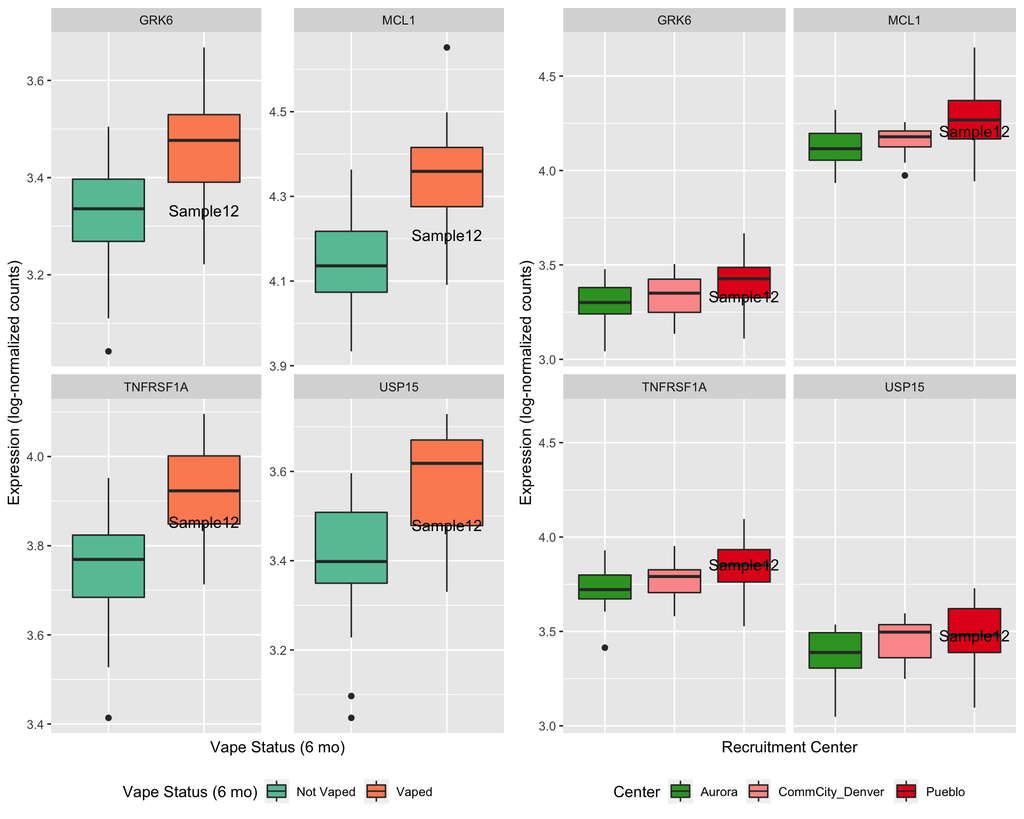

Looking at the vape status boxplots, there is an obvious visual difference in the mdedian values. For recruitment center plots, the median lines are much closer together. With the inclusion of the RUVr factors, sample 12 no longer is a suspected outlier.

### Figure 6: $log_{10}$(RUVr-Normalized Expression) of top genes (Vape Status Only)

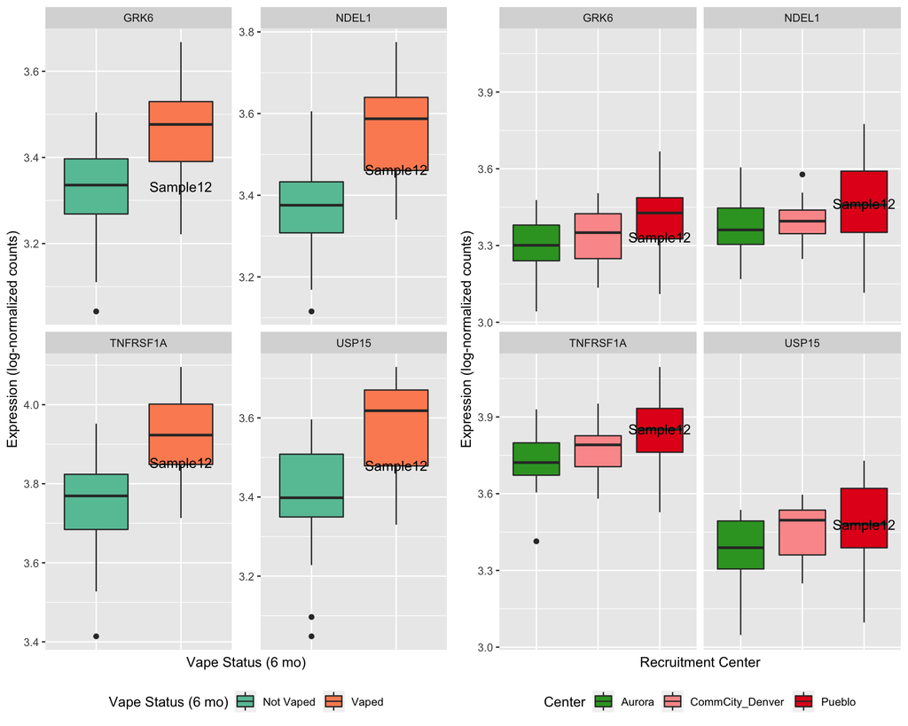

The plots for the *Vape Status Only* model has similar trends to the *Vape and Center* model. There do not appear to be center effects that are unaccounted for in comparison to the *Vape and Center* model.

### Figure 7: $\log_{10}$(RUVr-Normalized Expression) of top genes (Center Only)

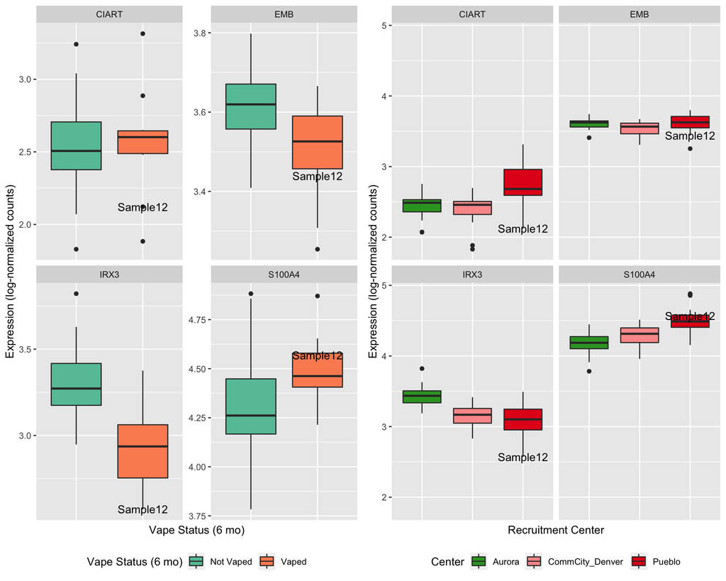

# Discussion/Conclusion

In the top genes (determined by adjusted p-value), there were no obvious visual differences between the model that tested both vape status *and* recruitment center and the model that tested only vape status (the model of interest). The top genes are consistent between the models as well. This is a desirable trend and suggests center is not adding greatly to the model above what vape status accounts for already.